# EDA Danych dotyczących Irysów

## O Danych

Zbiór danych zawiera informacje o trzech gatunkach irysów: Iris setosa, Iris versicolor, i Iris virginica.

Dane obejmują pomiary czterech cech: długość i szerokość działki kielicha oraz długość i szerokość płatka.

Każdy wiersz w zbiorze danych reprezentuje pojedynczy kwiat, a wartości pomiarów są podane w centymetrach.

Zbiór składa się z 150 próbek, po 50 dla każdego gatunku, i jest szeroko stosowany jako podstawowy zbiór danych do testowania algorytmów klasyfikacji oraz w nauce o danych i uczeniu maszynowym.

Kolumny:

- **długość kielicha (sepal length)** - Długość kielicha w cm
- **szerokość kielicha (sepal width)** - Szerokość kielicha w cm
- **długość płatka (petal length)** - Długość płatka w cm
- **szerokość płatka (petal width)** - Szerokość płatka w cm
- **klasa (class)** - Klasa irysa (setosa, versicolor, virginica)

|  | długość kielicha (sepal length) | szerokość kielicha (sepal width) | długość płatka (petal length) | szerokość płatka (petal width) | klasa (class) |
| --- | --- | --- | --- | --- | --- |
| 0 | 5.1 | 3.5 | 1.4 | 0.2 | Iris-setosa |
| 1 | 4.9 | 3.0 | 1.4 | 0.2 | Iris-setosa |
| 2 | 4.7 | 3.2 | 1.3 | 0.2 | Iris-setosa |
| 3 | 4.6 | 3.1 | 1.5 | 0.2 | Iris-setosa |
| 4 | 5.0 | 3.6 | 1.4 | 0.2 | Iris-setosa |
| ... | ... | ... | ... | ... | ... |
| 145 | 6.7 | 3.0 | 5.2 | 2.3 | Iris-virginica |
| 146 | 6.3 | 2.5 | 5.0 | 1.9 | Iris-virginica |
| 147 | 6.5 | 3.0 | 5.2 | 2.0 | Iris-virginica |
| 148 | 6.2 | 3.4 | 5.4 | 2.3 | Iris-virginica |
| 149 | 5.9 | 3.0 | 5.1 | 1.8 | Iris-virginica |

150 rows × 5 columns

# EDA for Iris flowers

## Klient: Gotoit

[figure not shown]

[figure not shown]

### 1. Ogólny przegląd danych

#### - przegląd losowych wierszów dla danych

|  | długość kielicha (sepal length) | szerokość kielicha (sepal width) | długość płatka (petal length) | szerokość płatka (petal width) | klasa (class) |
| --- | --- | --- | --- | --- | --- |
| 139 | 6.9 | 3.1 | 5.4 | 2.1 | Iris-virginica |
| 59 | 5.2 | 2.7 | 3.9 | 1.4 | Iris-versicolor |
| 82 | 5.8 | 2.7 | 3.9 | 1.2 | Iris-versicolor |
| 18 | 5.7 | 3.8 | 1.7 | 0.3 | Iris-setosa |
| 34 | 4.9 | 3.1 | 1.5 | 0.1 | Iris-setosa |
| 133 | 6.3 | 2.8 | 5.1 | 1.5 | Iris-virginica |
| 81 | 5.5 | 2.4 | 3.7 | 1.0 | Iris-versicolor |
| 64 | 5.6 | 2.9 | 3.6 | 1.3 | Iris-versicolor |
| 25 | 5.0 | 3.0 | 1.6 | 0.2 | Iris-setosa |
| 2 | 4.7 | 3.2 | 1.3 | 0.2 | Iris-setosa |

#### Wnioski: Dane wydają się być pełne, tzn. bez brakujących wartości

#### - wartości unikatowe dla badanego zbioru

```
długość kielicha (sepal length)     35
szerokość kielicha (sepal width)    23
długość płatka (petal length)       43
szerokość płatka (petal width)      22
klasa (class)                        3
dtype: int64
```

#### - duplikaty dla badanego zbioru

|  | długość kielicha (sepal length) | szerokość kielicha (sepal width) | długość płatka (petal length) | szerokość płatka (petal width) | klasa (class) |
| --- | --- | --- | --- | --- | --- |
| 34 | 4.9 | 3.1 | 1.5 | 0.1 | Iris-setosa |
| 37 | 4.9 | 3.1 | 1.5 | 0.1 | Iris-setosa |
| 142 | 5.8 | 2.7 | 5.1 | 1.9 | Iris-virginica |

|  | długość kielicha (sepal length) | szerokość kielicha (sepal width) | długość płatka (petal length) | szerokość płatka (petal width) |
| --- | --- | --- | --- | --- |
| count | 150.000000 | 150.000000 | 150.000000 | 150.000000 |
| mean | 5.843333 | 3.054000 | 3.758667 | 1.198667 |
| std | 0.828066 | 0.433594 | 1.764420 | 0.763161 |
| min | 4.300000 | 2.000000 | 1.000000 | 0.100000 |
| 25% | 5.100000 | 2.800000 | 1.600000 | 0.300000 |
| 50% | 5.800000 | 3.000000 | 4.350000 | 1.300000 |
| 75% | 6.400000 | 3.300000 | 5.100000 | 1.800000 |
| max | 7.900000 | 4.400000 | 6.900000 | 2.500000 |

#### Wnioski:

1. W zbiorze mamy 3 podzbiory Irysów,
2. Zbiór posiada 3 duplikaty które pozostawię do dalszej alanizy, ponieważ dane mają charakter ciągły i prawdopodobnie jest to wynik niedokładności pomiarowej,
3. Mamy 150 pojedyńczych lini, największy rozrzut - 50% można zauważyć wśród płatków, najmniejszy w kielichu - 15%.

### 2. Analiza brakujących wartości

```
długość kielicha (sepal length)     0
szerokość kielicha (sepal width)    0
długość płatka (petal length)       0
szerokość płatka (petal width)      0
klasa (class)                       0
dtype: int64
```

#### Wnioski:

1. Liczba brakujących wartości = 0,

### 3. Analiza pojedynczych zmiennych

```
array([[<Axes: title={'center': 'długość kielicha (sepal length)'}>,
        <Axes: title={'center': 'szerokość kielicha (sepal width)'}>],
       [<Axes: title={'center': 'długość płatka (petal length)'}>,
        <Axes: title={'center': 'szerokość płatka (petal width)'}>]],
      dtype=object)
```

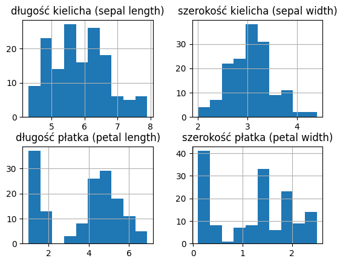

#### - Badanie normalności rozkładów

```
Kolumna 'długość kielicha (sepal length)':
Rozkład nie jest normalny

Kolumna 'szerokość kielicha (sepal width)':
Rozkład jest normalny

Kolumna 'długość płatka (petal length)':
Rozkład nie jest normalny

Kolumna 'szerokość płatka (petal width)':
Rozkład nie jest normalny
```

#### Wnioski

Dla kolumny szerokość kielicha (sepal width):

1. Około 68% wartości leży w zakresie μ ± σ,
2. Około 95% wartości leży w zakresie μ ± 2σ,
3. Około 99.7% wartości leży w zakresie μ ± 3σ

Dla pozostałych kolumn nie możemy zastosować podobnych właściwości.

### 4. Transformacja danych

Dane są pełnie wobec tego nie wymagają transformacji.

### 5. Analiza relacji między zmiennymi

[output not shown]

|  | długość kielicha (sepal length) | szerokość kielicha (sepal width) | długość płatka (petal length) | szerokość płatka (petal width) |
| --- | --- | --- | --- | --- |
| długość kielicha (sepal length) | 1.000000 | -0.109369 | 0.871754 | 0.817954 |
| szerokość kielicha (sepal width) | -0.109369 | 1.000000 | -0.420516 | -0.356544 |
| długość płatka (petal length) | 0.871754 | -0.420516 | 1.000000 | 0.962757 |
| szerokość płatka (petal width) | 0.817954 | -0.356544 | 0.962757 | 1.000000 |

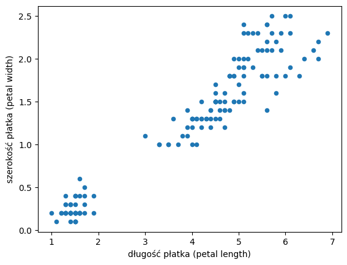

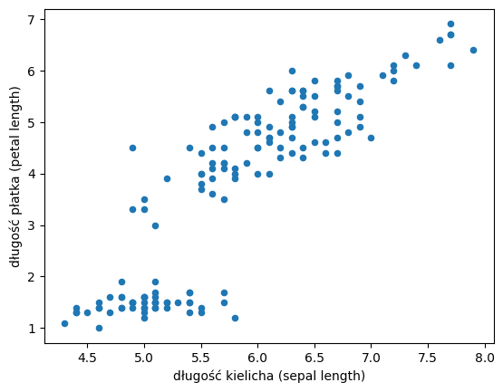

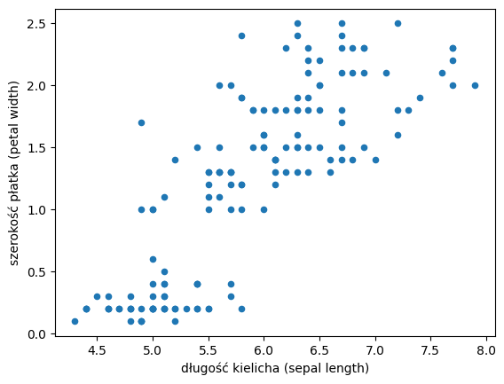

#### Wnioski

1. Bardzo silna korelacja dodatnia między długość kielicha (sepal length) a dlugością i szerokością płatka,
2. Bardzo silna korelacja między długość płatka (petal length) a szerokością płatka.

### 6. Analiza wartości odstających

#### Analiza danych po klasie (Wyzwanie z discorda)

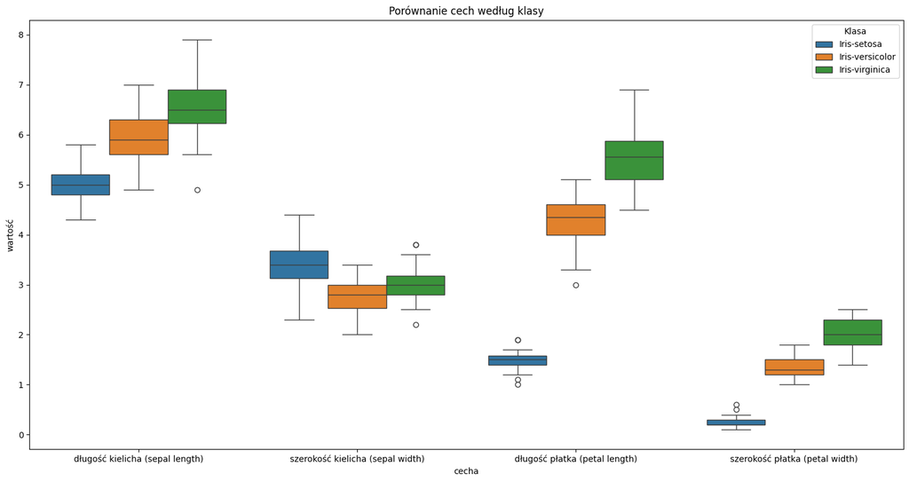

#### Wnioski:

1. Biorąc pod uwage cechę, wygląda na to że statystycznie Iris-viginica jest największy, następnie Iris-versicolor i na końcu Iris-setosa.
2. Wyjątek stanowi cecha 'szerokość kielicha (sepal width)' gdzie statystycznie największy jest Iris-setosa, Iris-virginica i na końcu Iris-versicolor.

|  | klasa (class) | długość kielicha (sepal length) std | szerokość kielicha (sepal width) std | długość płatka (petal length) std | szerokość płatka (petal width) std |
| --- | --- | --- | --- | --- | --- |
| 0 | Iris-setosa | 0.352490 | 0.381024 | 0.173511 | 0.107210 |
| 1 | Iris-versicolor | 0.516171 | 0.313798 | 0.469911 | 0.197753 |
| 2 | Iris-virginica | 0.635880 | 0.322497 | 0.551895 | 0.274650 |

#### Wnioski:

1. Największy rozrzut cechy widoczny jest dla 'Iris-virginica', najmniejszy dla 'Iris-setosa',
2. Iris-versicolor utrzymuje się jako wartość srodkowa,
3. Wyjątek stanowi 'szerokość kielicha (sepal width)' gdzie kolejność jest nastepujaca: Iris-versicolor => Iris-virginica => Iris-setosa.

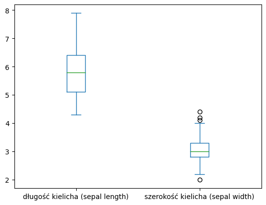

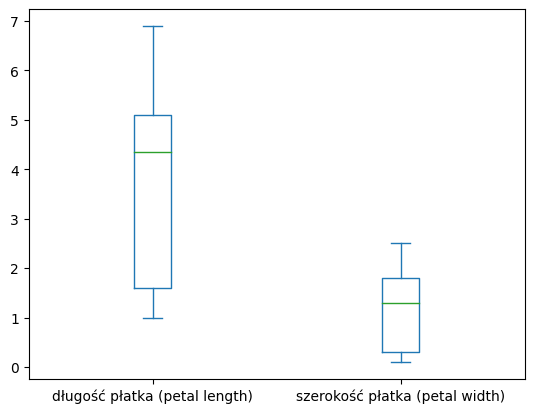

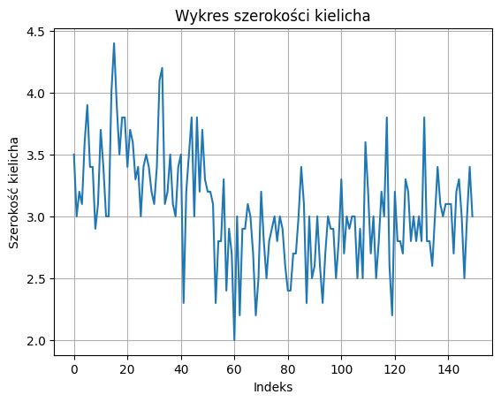